# 🌍 CLIMATE CHANGE MODELING

# Encoding sentiment labels

- Display the actual versus predicted classification results

```python
from sklearn.preprocessing import LabelEncoder
from sklearn.linear_model import LogisticRegression
from sklearn.metrics import accuracy_score, classification_report

# Initialize and fit the label encoder on y labels
label_encoder = LabelEncoder()
y_train = label_encoder.fit_transform(y_train)
y_test = label_encoder.transform(y_test)

# Continue with your model training and evaluation
classifier = LogisticRegression(max_iter=1000, random_state=42)
classifier.fit(X_train, y_train)

# Make predictions
y_pred = classifier.predict(X_test)

# Evaluate the model
accuracy = accuracy_score(y_test, y_pred)
print(f"Model Accuracy: {accuracy:.2f}")

# Classification report
print("\nClassification Report:")
print(classification_report(
    y_test,
    y_pred,
    target_names=[str(cls) for cls in label_encoder.classes_],  # <-- fix applied here
    zero_division=0
))
```

```
Model Accuracy: 0.99

Classification Report:
              precision    recall  f1-score   support

           0       0.99      1.00      1.00       104
           1       0.00      0.00      0.00         1

    accuracy                           0.99       105
   macro avg       0.50      0.50      0.50       105
weighted avg       0.98      0.99      0.99       105
```

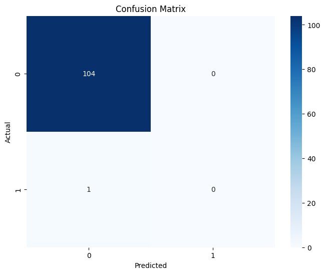

```python
# Confusion Matrix
conf_matrix = confusion_matrix(y_test, y_pred)


plt.figure(figsize=(8, 6))
sns.heatmap(conf_matrix, annot=True, fmt='d', cmap='Blues', xticklabels=label_encoder.classes_, yticklabels=label_encoder.classes_)
plt.xlabel('Predicted')
plt.ylabel('Actual')
plt.title('Confusion Matrix')
plt.show()
```

# Analysis of Sentiment Trends

```python
# Convert 'date' column to datetime and remove timezone if present
df['date'] = pd.to_datetime(df['date']).dt.tz_localize(None)
df['YearMonth'] = df['date'].dt.to_period('M')  # Extract Year-Month
```

```python
trend_df =df.groupby(['YearMonth', 'Sentiment']).size().unstack(fill_value=0)
trend_df= trend_df.div(trend_df.sum(axis=1), axis=0)  # Convert counts to proportions
```

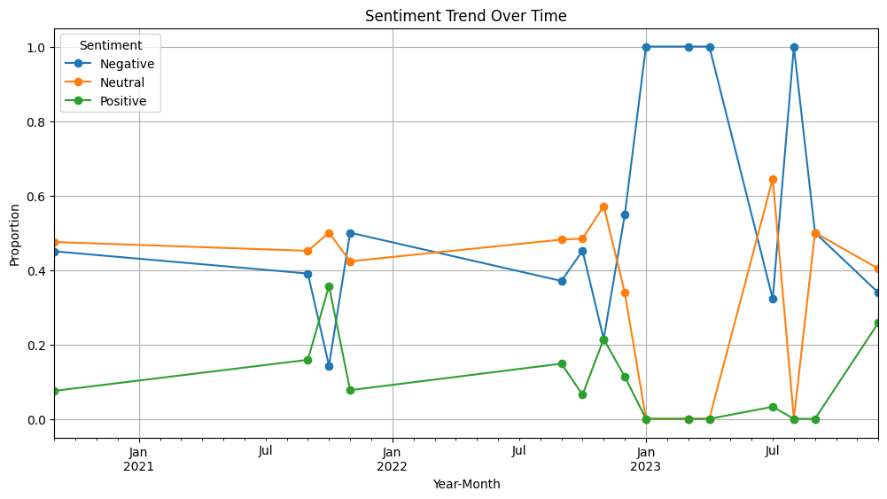

```python
plt.figure(figsize=(12, 6))
trend_df.plot(kind='line', figsize=(12, 6), marker='o', title="Sentiment Trend Over Time")
plt.ylabel("Proportion")
plt.xlabel("Year-Month")
plt.grid(True)
plt.legend(title="Sentiment")
plt.show()
```

# Saving a the trained model

```python
import joblib

# Save the trained model and preprocessing tools
joblib.dump(classifier, "sentiment_model.pkl")  # ← change 'clf' to 'classifier'
joblib.dump(tfidf_vectorizer, "tfidf_vectorizer.pkl")
joblib.dump(label_encoder, "label_encoder.pkl")

print("Model and encoders saved successfully!")
```

```
Model and encoders saved successfully!
```

# Execution complete

- Model Deployment and Making Predictions on New Text data

```python
# Load the saved model, vectorizer, and label encoder
loaded_model = joblib.load("sentiment_model.pkl")
loaded_vectorizer = joblib.load("tfidf_vectorizer.pkl")
loaded_label_encoder = joblib.load("label_encoder.pkl")

# New text data for prediction
new_texts = ["I have also seen the podcast. I congratulate you both. 🎉🎉 Many many congratulations & best wishes 🎉🎉🎉🎉🎉 May God bless you both. 🎉", "Please visit barbeque nation , im sanatani ,but faiza is non vegetarian she might be having craving for non veg meal .. its perfect place to have good variety of food unlimited for 399 for veg  and 449 for non veg with great ambience and hospitality."]

# Preprocess the text
new_texts_transformed = loaded_vectorizer.transform(new_texts)

# Predict using the loaded model
predictions = loaded_model.predict(new_texts_transformed)

# Decode the predicted labels
decoded_predictions = loaded_label_encoder.inverse_transform(predictions)
print("Predicted Sentiments:", decoded_predictions)
```

```
Predicted Sentiments: [0 0]
```

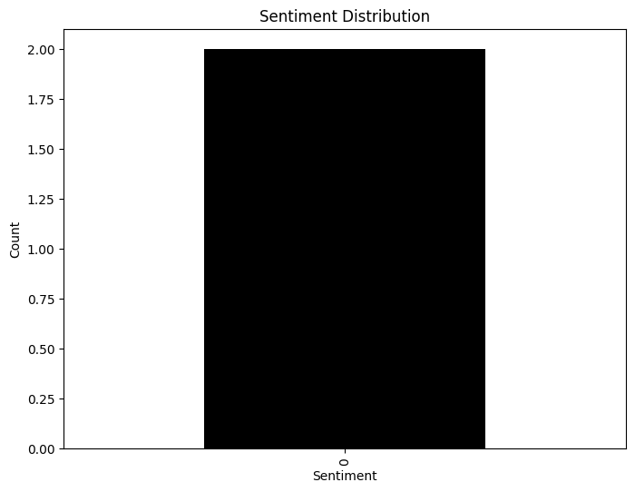

```python
sentiments = ['0', '0']
sentiment_counts = pd.Series(sentiments).value_counts()


sentiment_counts.plot(kind='bar', color=['black', 'green'], figsize=(8, 6))
plt.title("Sentiment Distribution")
plt.xlabel("Sentiment")
plt.ylabel("Count")
plt.show()
```

```python
# Get probabilities for each class
probabilities = loaded_model.predict_proba(new_texts_transformed)
for i, text in enumerate(new_texts):
    print(f"Text: {text}")
    print(f"Predicted: {decoded_predictions[i]}, Probability: {probabilities[i]}")
```

```
Text: I have also seen the podcast. I congratulate you both. 🎉🎉 Many many congratulations & best wishes 🎉🎉🎉🎉🎉 May God bless you both. 🎉
Predicted: 0, Probability: [0.99546668 0.00453332]
Text: Please visit barbeque nation , im sanatani ,but faiza is non vegetarian she might be having craving for non veg meal .. its perfect place to have good variety of food unlimited for 399 for veg  and 449 for non veg with great ambience and hospitality.
Predicted: 0, Probability: [0.99522833 0.00477167]
```

# Text preprocessing and feature extraction completed

# Thank You

This project was completed independently, and I am grateful for the opportunity to explore and learn through hands-on experimentation. Working solo provided valuable experience in managing each phase of the machine learning pipeline — from data preprocessing and sentiment analysis to visualization and model evaluation. This experience has not only enhanced my technical proficiency in NLP and classification techniques but also deepened my understanding of climate-related trends and the power of data-driven insights for environmental awareness.

Prajakta Koli +91 9359988469 koliprjkt@gmail.com